# 1. Introduction

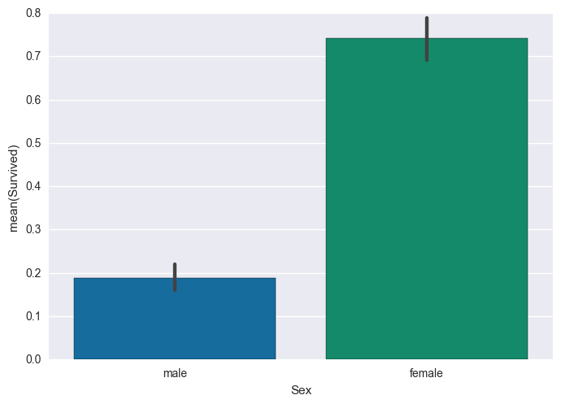

```python
sns.set(style="darkgrid")
sns.barplot(data=titanic_df, x='Sex',y='Survived',palette="colorblind")
sns.plt.show()
```

**Summary of plots:** It is evident from looking at the bar charts that being a women significantly increased your chances of survival on the titanic.

### 2.3.2 What relevance does Age have in increasing chance of surviving?

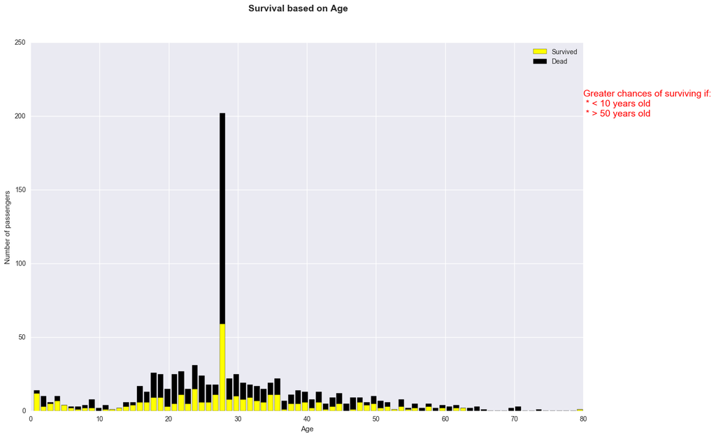

```python
figure = plt.figure(figsize=(15,10))
plt.hist([titanic_df[titanic_df['Survived']==1]['Age'],
          titanic_df[titanic_df['Survived']==0]['Age']],
         stacked=True,
         color = ['yellow','black'],
         bins = 80,
         label = ['Survived','Dead'])
plt.xlabel('Age')
plt.ylabel('Number of passengers')
plt.legend()
plt.suptitle('Survival based on Age', fontsize=14, fontweight='bold')
plt.text(80, 200,'Greater chances of surviving if:\n * < 10 years old \n * > 50 years old', fontsize=14, color='red')
```

- the ages 9-10 do not appear to fit within the above statement.
- the ages 35-36 had a greater ratio of survival

### 2.3.3 What relevance does Fare Price have in increasing chance of surviving?

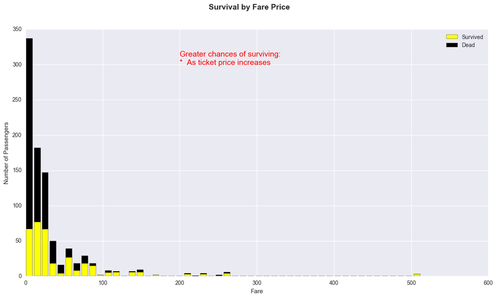

```python
figure = plt.figure(figsize=(15,8))  #15 grids
plt.hist([titanic_df[titanic_df['Survived']==1]['Fare'],
          titanic_df[titanic_df['Survived']==0]['Fare']],
         stacked=True,
         color = ['yellow','black'],
         bins = 50,
         label = ['Survived','Dead'])
plt.xlabel('Fare')
plt.ylabel('Number of Passengers')
plt.legend()
plt.suptitle('Survival by Fare Price', fontsize=14, fontweight='bold')
plt.text(200, 300,'Greater chances of surviving: \n*  As ticket price increases', fontsize=14, color='red')
```

**Summary of Findings:** By looking at the ratio of yellow to black in the stacked bars it appears that as the passengers ticket price increased so did they chances of survival

**Interesting Finding:** The ticket price between 40-50 is an exception to the above statement

#### Combine Age & Ticket price data to create a Scatter Plot

Because a child ticket price is often much cheaper than an adults I've made use of a scatter plot to see the relationship of the two variables in context of survival

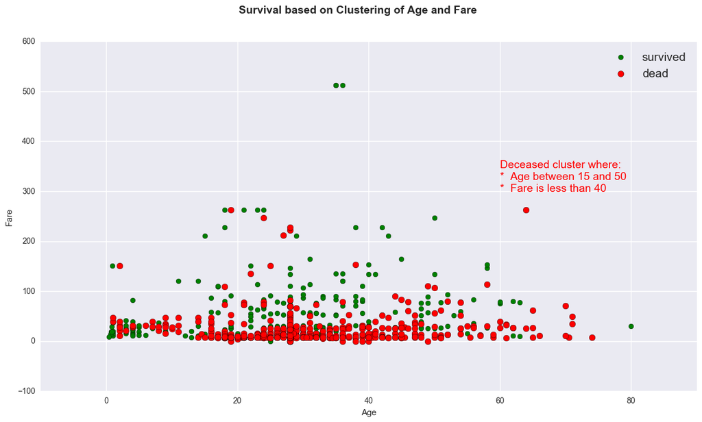

```python
plt.figure(figsize=(15,8))
ax = plt.subplot()

# Plot Survived
ax.scatter(titanic_df[titanic_df['Survived']==1]['Age'],
           titanic_df[titanic_df['Survived']==1]['Fare'],
           c='green',
           s=40)

# Plot Deceased
ax.scatter(titanic_df[titanic_df['Survived']==0]['Age'],
           titanic_df[titanic_df['Survived']==0]['Fare'],
           c='red',
           s=60)

ax.set_xlabel('Age')
ax.set_ylabel('Fare')
ax.legend(('survived','dead'),
          scatterpoints=1,
          loc='upper right',
          fontsize=15,)

plt.suptitle('Survival based on Clustering of Age and Fare', fontsize=14, fontweight='bold')
plt.text(60, 300,'Deceased cluster where: \n*  Age between 15 and 50 \n*  Fare is less than 40', fontsize=14, color='red')
```

**Summary of Findings:** Fare price only appears to be relevant for those aged >=15

**Is there a correlation with Fare Price and Passenger Class?**

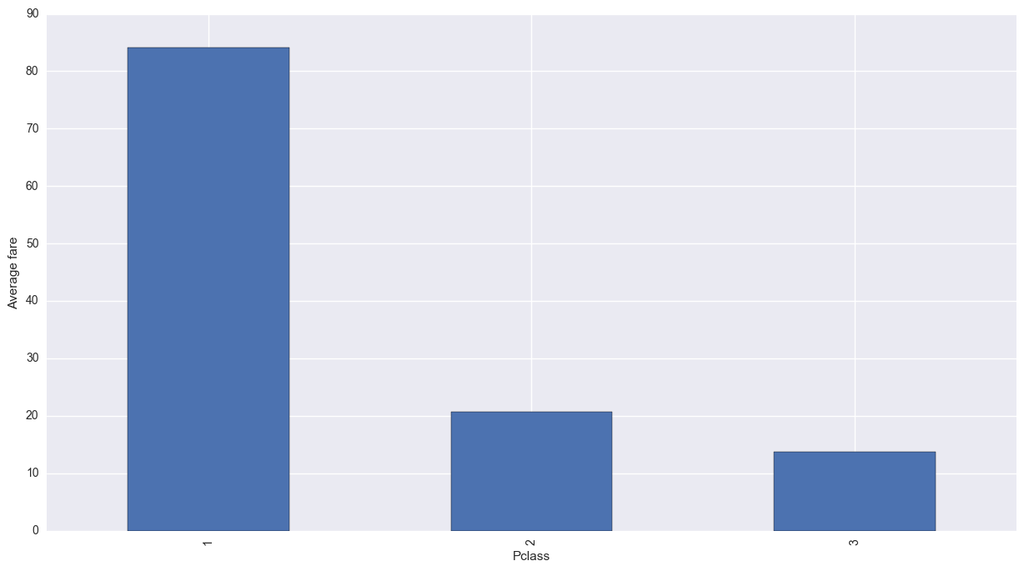

```python
ax = plt.subplot(111)
ax.set_ylabel('Average fare')
titanic_df.groupby('Pclass').mean()['Fare'].plot(kind='bar',figsize=(15,8), ax = ax)
```

**Summary of Findings:** Higher fare prices correlate with Passenger Class

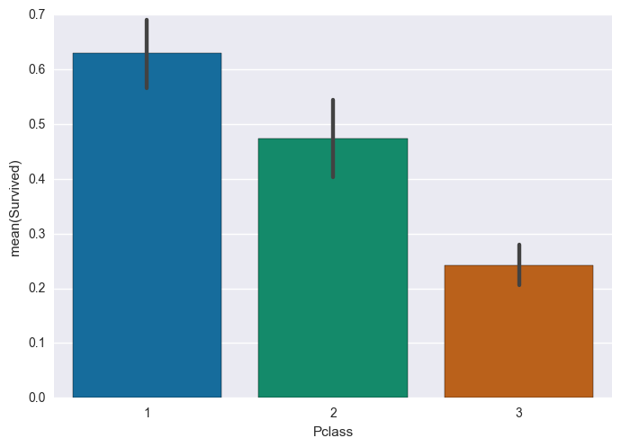

```python
sns.barplot(data=titanic_df, x="Pclass", y='Survived', palette="colorblind")
sns.plt.show()
```

## 3.0 Tentative Conclusion

All of the following appear to have a significant relevant in determining the chance of survival

- Gender: Female
- Age: less than 15
- Fare Price: > 50
- Passenger Class: 1

To validate further statistical analysis will be required to validate the accuracy of this finding made through visual analysis.

## 4.0 References

- http://seaborn.pydata.org/
- http://stackoverflow.com/questions/22470690/get-list-of-pandas-dataframe-columns-based-on-data-type
- http://pandas.pydata.org/pandas-docs/version/0.15.2/tutorials.html
- http://ahmedbesbes.com/how-to-score-08134-in-titanic-kaggle-challenge.html
- http://matplotlib.org/
- Video lectures of the course (Intro to Data Analysis)
- Kaggle titanic competition page (https://www.kaggle.com/c/titanic)